# TENG_HW1

Angela V Teng (Amber) at2507

2/24/2020

### 0 SETTING UP

Set up libraries, load packages, set working directory.

### QUESTION 1

First we’ll use the data from the U.S. inaugural addresses available in quanteda. Let’s first look at the inaugural addresses given by Richard Nixon in 1969 and 1973.

```r
# Load the presidential inaugural address texts (https://rdrr.io/cran/quanteda/man/data_corpus_inaugural.html)
inaug <- data_corpus_inaugural
# data_corpus_inaugural

summary(data_corpus_inaugural)
```

```
## Corpus consisting of 58 documents:
##
##             Text Types Tokens Sentences Year  President       FirstName
##  1789-Washington   625   1538        23 1789 Washington          George
##  1793-Washington    96    147         4 1793 Washington          George
##       1797-Adams   826   2578        37 1797      Adams            John
##   1801-Jefferson   717   1927        41 1801  Jefferson          Thomas
##   1805-Jefferson   804   2381        45 1805  Jefferson          Thomas
##     1809-Madison   535   1263        21 1809    Madison           James
##     1813-Madison   541   1302        33 1813    Madison           James
##      1817-Monroe  1040   3680       121 1817     Monroe           James
##      1821-Monroe  1259   4886       129 1821     Monroe           James
##       1825-Adams  1003   3152        74 1825      Adams     John Quincy
##     1829-Jackson   517   1210        25 1829    Jackson          Andrew
##     1833-Jackson   499   1269        29 1833    Jackson          Andrew
##    1837-VanBuren  1315   4165        95 1837  Van Buren          Martin
##    1841-Harrison  1896   9144       210 1841   Harrison   William Henry
##        1845-Polk  1334   5193       153 1845       Polk      James Knox
##      1849-Taylor   496   1179        22 1849     Taylor         Zachary
##      1853-Pierce  1165   3641       104 1853     Pierce        Franklin
##    1857-Buchanan   945   3086        89 1857   Buchanan           James
##     1861-Lincoln  1075   4006       135 1861    Lincoln         Abraham
##     1865-Lincoln   360    776        26 1865    Lincoln         Abraham
##       1869-Grant   485   1235        40 1869      Grant      Ulysses S.
##       1873-Grant   552   1475        43 1873      Grant      Ulysses S.
##       1877-Hayes   831   2716        59 1877      Hayes   Rutherford B.
##    1881-Garfield  1021   3212       111 1881   Garfield        James A.
##   1885-Cleveland   676   1820        44 1885  Cleveland          Grover
##    1889-Harrison  1352   4722       157 1889   Harrison        Benjamin
##   1893-Cleveland   821   2125        58 1893  Cleveland          Grover
##    1897-McKinley  1232   4361       130 1897   McKinley         William
##    1901-McKinley   854   2437       100 1901   McKinley         William
##   1905-Roosevelt   404   1079        33 1905  Roosevelt        Theodore
##        1909-Taft  1437   5822       159 1909       Taft  William Howard
##      1913-Wilson   658   1882        68 1913     Wilson         Woodrow
##      1917-Wilson   549   1656        59 1917     Wilson         Woodrow
##     1921-Harding  1169   3721       148 1921    Harding       Warren G.
##    1925-Coolidge  1220   4440       196 1925   Coolidge          Calvin
##      1929-Hoover  1090   3865       158 1929     Hoover         Herbert
##   1933-Roosevelt   743   2062        85 1933  Roosevelt     Franklin D.
```

[output cut: 10 more lines]

```
##      1977-Carter   527   1376        52 1977     Carter           Jimmy
##      1981-Reagan   902   2790       128 1981     Reagan          Ronald
##      1985-Reagan   925   2921       123 1985     Reagan          Ronald
##        1989-Bush   795   2681       141 1989       Bush          George
##     1993-Clinton   642   1833        81 1993    Clinton            Bill
##     1997-Clinton   773   2449       111 1997    Clinton            Bill
##        2001-Bush   621   1808        97 2001       Bush       George W.
##        2005-Bush   773   2319       100 2005       Bush       George W.
##       2009-Obama   938   2711       110 2009      Obama          Barack
##       2013-Obama   814   2317        88 2013      Obama          Barack
##       2017-Trump   582   1660        88 2017      Trump       Donald J.
##
## Source: Gerhard Peters and John T. Woolley. The American Presidency Project.
## Created: Tue Jun 13 14:51:47 2017
## Notes: http://www.presidency.ucsb.edu/inaugurals.php
```

```r
# head(docvars(data_corpus_inaugural), 10)
# do basic data exploration
# head(inaug)
# a corpus consists ofs: (1) documents: text + doc level data (2) corpus metadata (3) extras (settings)

head(docvars(inaug))  # document-level variables
```

```
##                 Year  President FirstName
## 1789-Washington 1789 Washington    George
## 1793-Washington 1793 Washington    George
## 1797-Adams      1797      Adams      John
## 1801-Jefferson  1801  Jefferson    Thomas
## 1805-Jefferson  1805  Jefferson    Thomas
## 1809-Madison    1809    Madison     James
```

```r
metacorpus(inaug)  # corpus-level variables
```

```
## $source
## [1] "Gerhard Peters and John T. Woolley. The American Presidency Project."
##
## $notes
## [1] "http://www.presidency.ucsb.edu/inaugurals.php"
##
## $created
## [1] "Tue Jun 13 14:51:47 2017"
```

```r
# ndoc identifies the number of documents in a corpus
ndocs <- ndoc(inaug)
ndocs
```

```
## [1] 58
```

```r
# summary of the corpus (provides some summary statistics on the text combined with the metadata)
corpusinfo <- summary(inaug, n = ndocs)  # note n default is 100
head(corpusinfo)
```

```
##              Text Types Tokens Sentences Year  President FirstName
## 1 1789-Washington   625   1538        23 1789 Washington    George
## 2 1793-Washington    96    147         4 1793 Washington    George
## 3      1797-Adams   826   2578        37 1797      Adams      John
## 4  1801-Jefferson   717   1927        41 1801  Jefferson    Thomas
## 5  1805-Jefferson   804   2381        45 1805  Jefferson    Thomas
## 6    1809-Madison   535   1263        21 1809    Madison     James
```

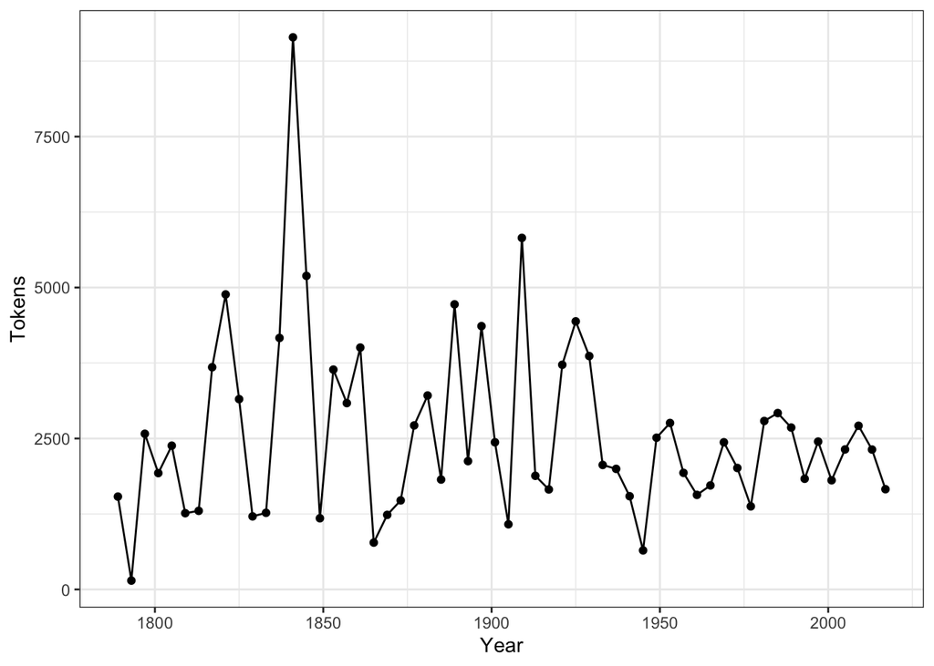

```r
# does tokens >= types always hold?

# quick visualization
token_plot <- ggplot(data = corpusinfo, aes(x = Year, y = Tokens, group = 1)) + geom_line() + geom_point() + theme_bw()
token_plot
```

```r
# subset corpus to include only Nixon ---------------------
# summary(corpus_subset(inaug, President == "Nixon"))
nixon_inaug <- corpus_subset(inaug, President == "Nixon")
# head(docvars(nixon_inaug))
```

#### QUESTION 1 A

1. Calculate the TTR of each of these speeches and report your findings.

```r
# 2.1 Example using data from the corpus of inaugural speeches
tokens <- tokens(nixon_inaug, remove_punct = TRUE)
# tokens
num_tokens <- sum(lengths(tokens))
# num_tokens

inaug_nixon_dfm <- dfm(nixon_inaug)
# inaug_nixon_dfm

# TOKEN TYPE RATTIO = TOTAL TYPES / TOTAL TOKENS
# 3.1 Type Token Ratio

# Num tokens per document
num_tokens <- lengths(tokens)
num_tokens
```

```
## 1969-Nixon 1973-Nixon
##       2124       1802
```

```r
num_types <- ntype(tokens)
num_types
```

```
## 1969-Nixon 1973-Nixon
##        737        537
```

```r
nixon_inaug_df <- data.frame("num_tokens" = num_tokens,
                              "num_types" = num_types,
                              "year" = data_corpus_inaugural$document$Year,
                              "president" =data_corpus_inaugural$document$President)
nixon_inaug_df
```

```
##    num_tokens num_types year  president
## 1        2124       737 1789 Washington
## 2        1802       537 1793 Washington
## 3        2124       737 1797      Adams
## 4        1802       537 1801  Jefferson
## 5        2124       737 1805  Jefferson
## 6        1802       537 1809    Madison
## 7        2124       737 1813    Madison
## 8        1802       537 1817     Monroe
## 9        2124       737 1821     Monroe
## 10       1802       537 1825      Adams
## 11       2124       737 1829    Jackson
## 12       1802       537 1833    Jackson
## 13       2124       737 1837  Van Buren
## 14       1802       537 1841   Harrison
```

[output cut: 44 more lines]

```r
nixon_inaug_df  <- nixon_inaug_df %>% mutate(TTR = num_types / num_tokens)

head(nixon_inaug_df)
```

```
##   num_tokens num_types year  president       TTR
## 1       2124       737 1789 Washington 0.3469868
## 2       1802       537 1793 Washington 0.2980022
## 3       2124       737 1797      Adams 0.3469868
## 4       1802       537 1801  Jefferson 0.2980022
## 5       2124       737 1805  Jefferson 0.3469868
## 6       1802       537 1809    Madison 0.2980022
```

```r
# nixon_inaug_df

# 3.2 Mean per-document TTR scores by year, president
TTR_by_year_president <- nixon_inaug_df %>% group_by(year, president) %>% summarise(mean_ttr = mean(TTR, na.rm = TRUE))

View(TTR_by_year_president)
# select only nixon
nixon_ttr <- TTR_by_year_president[which (TTR_by_year_president$president=='Nixon'), ]
nixon_ttr
```

```
## # A tibble: 2 x 3
## # Groups:   year [2]
##    year president mean_ttr
##   <dbl> <fct>        <dbl>
## 1  1969 Nixon        0.298
## 2  1973 Nixon        0.347
```

TTR = Total Types/ Total Tokens

#### QUESTION 1 B

2. Create a document feature matrix of the two speeches, with no pre-processing other than to remove the punctuation{be sure to check the options on " in R as appropriate. Calculate the cosine similarity between the two documents with quanteda. Report your findings.

```r
# create a document frequency matrix
inaug_nixon_dfm <- dfm(nixon_inaug)

# M <- nfeat(inaug_nixon_dfm)  # number of features = number of types
# M

# inspect the first few features
inaug_nixon_dfm[, 1:10]  # 10% sparse
```

```
## Document-feature matrix of: 2 documents, 10 features (10.0% sparse).
## 2 x 10 sparse Matrix of class "dfm"
##             features
## docs         senator dirksen   , mr   . chief justice vice president
##   1969-Nixon       1       1 134  2 105     1       1    2         3
##   1973-Nixon       1       0  96  3  69     1       1    1         1
##             features
## docs         johnson
##   1969-Nixon       1
##   1973-Nixon       0
```

```r
# Print out dimensions of dfm and see how many rows are present
dim(inaug_nixon_dfm)
```

```
## [1]   2 992
```

```r
# top features in dfm without removing punctuation
topfeatures(inaug_nixon_dfm)
```

```
##   , the   .  of  to  in  we and our   -
## 230 219 174 162 134 119 112  89  79  76
```

```r
# remove punctuation

# NOTE: lowercase argument is by default TRUE
# punctuation
# note that this is for 2 documents, 1969 and 1973
inaug_nixon_dfm <- dfm(nixon_inaug , remove_punct = TRUE)
inaug_nixon_dfm[, 1:20]
```

```
## Document-feature matrix of: 2 documents, 20 features (10.0% sparse).
## 2 x 20 sparse Matrix of class "dfm"
##             features
## docs         senator dirksen mr chief justice vice president johnson
##   1969-Nixon       1       1  2     1       1    2         3       1
##   1973-Nixon       1       0  3     1       1    1         1       0
##             features
## docs         humphrey my fellow americans and citizens of the world
##   1969-Nixon        1  7      2         1  39        1 94 136    13
##   1973-Nixon        0  1      1         0  50        1 68  83    16
##             features
## docs         community  i ask
##   1969-Nixon         1 21   2
##   1973-Nixon         1 12   3
```

```r
# calculate cosine similarity

# 5.1 Cosine similarity--take the dot product of two vectors
# cos = x*y/|x||y|
calculate_cosine_similarity <- function(vec1, vec2) {
  nominator <- vec1 %*% vec2  # %*% specifies dot product rather than entry by entry multiplication (we could also do: sum(x * y))
  denominator <- sqrt(vec1 %*% vec1)*sqrt(vec2 %*% vec2)
  return(nominator/denominator)
}

# Select texts from each year only.
nixon_1969_text <- texts(nixon_inaug)[1]
nixon_1973_text <- texts(nixon_inaug)[2]

# Make a dfm of these two text documents
nixon_all_dfm <- dfm(c(nixon_1969_text, nixon_1973_text), remove = stopwords("english"), stem = TRUE)

# Calculate similarity
similarity_nixon_1969_1973_with_preprocessing <- textstat_simil(nixon_all_dfm, margin = "documents", method = "cosine")
as.matrix(similarity_nixon_1969_1973_with_preprocessing)
```

```
##            1969-Nixon 1973-Nixon
## 1969-Nixon  1.0000000  0.9143316
## 1973-Nixon  0.9143316  1.0000000
```

### QUESTION 2

Consider different preprocessing choices you could make. For each of the following parts of this question, you have three tasks: (i) make a theoretical argument for how it should affect the TTR of each document and the similarity of the two documents (ii) re-do question (1a) with the preprocessing option indicated and (iii) redo question (1b) with the preprocessing option indicated.

To be clear, you must repeat tasks (i-iii) for each pre-processing option below. You should remove punctuation in each step. (a) Stemming the words? (b) Removing stop words? (c) Converting all words to lowercase? (d) Does tf-idf weighting make sense here? Explain why or why not.

### QUESTION 3

Take the following two headlines:

“Trump Says He’s `Not Happy’ With Border Deal, but Doesn’t Say if He Will Sign It.”

“Trump `not happy’ with border deal, weighing options for building wall.”

1. Calculate the Euclidean distance between these sentences by hand–that is, you can use base R, but you can’t use distance functions from quanteda or similar. You are allowed to use quanteda to tokenize or create a DFM. Use whatever pre-processing of the text you want, but justify your choice. Report your findings.

```r
# tokenize the texts
txt <- c(text1 = "Trump Says He's `Not Happy' With Border Deal, but Doesn't Say if He Will Sign It.",
         text2 = "Trump `not happy' with border deal, weighing options for building wall.")
tokens(txt)
```

```
## tokens from 2 documents.
## text1 :
##  [1] "Trump"   "Says"    "He's"    "`"       "Not"     "Happy"   "'"
##  [8] "With"    "Border"  "Deal"    ","       "but"     "Doesn't" "Say"
## [15] "if"      "He"      "Will"    "Sign"    "It"      "."
##
## text2 :
##  [1] "Trump"    "`"        "not"      "happy"    "'"        "with"
##  [7] "border"   "deal"     ","        "weighing" "options"  "for"
## [13] "building" "wall"     "."
```

```r
tokens(txt, remove_numbers = TRUE,  remove_punct = TRUE)
```

```
## tokens from 2 documents.
## text1 :
##  [1] "Trump"   "Says"    "He's"    "Not"     "Happy"   "With"    "Border"
##  [8] "Deal"    "but"     "Doesn't" "Say"     "if"      "He"      "Will"
## [15] "Sign"    "It"
##
## text2 :
##  [1] "Trump"    "not"      "happy"    "with"     "border"   "deal"
##  [7] "weighing" "options"  "for"      "building" "wall"
```

2. Calculate the Manhattan distance between these sentences by hand. Report your findings.
3. Calculate the cosine similarity between these sentences by hand. Report your findings.

### QUESTION 4

One of the earliest and most famous applications of statistical textual analysis was to deter-mine the authorship of texts. You now get to do the same! You will be using the stylest package. To get the texts for this exercise you will need the gutenbergr package.

1. First you will need to get the data from Project Gutenberg using their gutenbergr package. Download the first four novels for each of the following authors:
- Austen, Jane (Persuasion, Northanger Abbey, Mansfield Park, and Emma),
- Dickens, Charles (A Christmas Carol in Prose; Being a Ghost Story of Christmas, A Tale of Two Cities, The Mystery of Edwin Drood, and The Pickwick Papers),
- Alcott, Louisa May (Flower Fables, Little Women, Eight Cousins, and Jack and Jill ),
- Bronte, Charlotte (The Professor, Jane Eyre: An Autobiography, Villette, and Shirley).

From each of these novels extract a short excerpt (e.g. 500 lines of text).

2. Next you will need to organize the data as required by the package. Create a table (i.e. a dataframe) with one column for the text excerpts and one column identifying the author of each excerpt (although not required to t the model, also create a column for the title of the novel which the excerpt belongs to). Print the str() of your table.
3. Now use the stylest select vocab function to select the terms you will include in your model. Note, this function allows you to include some pre-processing options. Justify any pre-processing choices you make. What percentile (of term frequency) has the best prediction rate? Also report the mean rate of incorrectly predicted speakers of held-out texts.
4. Use your optimal percentile from above to subset the terms to be included in your model (this requires you use the stylest terms function). Now go ahead and t the model using stylest fit. The output of this function includes information on the rate at which each author uses each term (the value is labeled rate). Report the top 5 terms (in terms of usage rate) for each author. Do these terms make sense?
5. Choose any two authors, take the ratio of their rate vectors (make sure dimensions are in the same order) and arrange the resulting vector from largest to smallest values. What are the top 5 terms according to this ratio? How would you interpret this ordering?
6. Load the mystery excerpt provided. According to your tted model, who is the most likely author?
7. Use textstat collocation to inspect 2-grams with min count = 5 from your DFM of all 16 labeled novels. Report the 10 collocations with the largest  value. Report the 10 collocations with the largest count. Discuss which set of n-grams is likely to be multi-word expressions.

### * FINISHING UP

```r
# *.1 Save workspace after running it -- all objects, functions, etc  (e.g. if you have run something computationally intensive and want to save the object for later use)
# Similar to pickle() in Python

save.image("workspace_hw1.RData")

# *.2 Pick up where you left off (but note that the workspace does not include packages. You need packrat for that)

rm(list = ls())

load("workspace_hw1.RData")
```